# Almetyevsk metagenome statistics 2

Oxana Kolpakova

2023-12-09

## 1. Предобработка

Статистика для файла Kraken_taxonomic_report_S1S2S3S4.csv

- fastp -q 20 -l 50 –trim_poly_g
- kraken2 Confidence 0.1, Minimum Base Quality 20, Standart DB (Galaxy)
- Kraken taxonomic report (Galaxy)

## 2. Фильтрация

Контоминация человеком не обнаружена. Фильтрация не проводилась.

## 3. Определение самых представленных видов.

Создадим таблицу из 15 самых представленных видов

| #ID…1 | S1 | #ID…3 | S2 | #ID…5 | S3 | #ID…7 | S4 |
| --- | --- | --- | --- | --- | --- | --- | --- |
| root | 701 | root | 866 | root | 808 | root | 741 |
| Bacteria_2 | 426 | Bacteria_2 | 551 | Bacteria_2 | 504 | Bacteria_2 | 424 |
| Azorhizobium_caulinodans | 206 | Azorhizobium | 274 | Azorhizobium | 262 | Azorhizobium_caulinodans | 216 |
| Azorhizobium | 205 | Azorhizobium_caulinodans | 240 | Azorhizobium_caulinodans | 242 | Azorhizobium | 182 |
| Buchnera_aphidicola | 162 | Cellvibrio | 184 | Cellvibrio | 218 | Buchnera_aphidicola | 152 |
| Cellvibrio | 152 | Buchnera_aphidicola | 184 | Buchnera_aphidicola | 202 | Cellvibrio | 144 |
| [Cellvibrio]_gilvus | 145 | [Cellvibrio]_gilvus | 156 | [Cellvibrio]_gilvus | 189 | [Cellvibrio]_gilvus | 143 |
| Dictyoglomus | 135 | Dictyoglomus_thermophilum | 148 | Dictyoglomus | 167 | Dictyoglomus_thermophilum | 120 |
| Methylophilus_methylotrophus | 131 | Dictyoglomus | 134 | Methylophilus | 143 | Methylophilus | 111 |
| Phenylobacterium | 121 | Methylophilus_methylotrophus | 131 | Dictyoglomus_thermophilum | 133 | Methylophilus_methylotrophus | 106 |
| Methylophilus | 120 | Methylophilus | 114 | Methylophilus_methylotrophus | 132 | Pelobacter | 102 |
| Dictyoglomus_thermophilum | 120 | Pelobacter | 87 | Phenylobacterium | 119 | Pelobacter_carbinolicus | 100 |
| Pelobacter | 110 | Phenylobacterium | 85 | Pelobacter | 102 | Phenylobacterium_immobile | 96 |
| Shewanella_putrefaciens | 95 | Pelobacter_carbinolicus | 83 | Pelobacter_carbinolicus | 102 | Dictyoglomus | 95 |
| Pelobacter_carbinolicus | 94 | Phenylobacterium_immobile | 82 | Phenylobacterium_immobile | 95 | Shewanella | 84 |

Создадим список уникальных видов из предыдущих таблиц.

| #ID |
| --- |
| root |
| Bacteria_2 |
| Azorhizobium_caulinodans |
| Azorhizobium |
| Buchnera_aphidicola |
| Cellvibrio |
| [Cellvibrio]_gilvus |
| Dictyoglomus |
| Methylophilus_methylotrophus |
| Phenylobacterium |
| Methylophilus |
| Dictyoglomus_thermophilum |
| Pelobacter |
| Shewanella_putrefaciens |
| Pelobacter_carbinolicus |
| Phenylobacterium_immobile |
| Shewanella |

## 4. Расчёт индексов альфа и бета-разнообразия в сообществах для выявления различий/сходств в составах сообществ. Построение PCoA/NMDS графиков на основании расстояний Брея-Кертиса.

|  | Observed | Chao1 | se.chao1 | Shannon | Simpson | InvSimpson |
| --- | --- | --- | --- | --- | --- | --- |
| S1 | 559 | 1339.016 | 134.3857 | 4.571339 | 0.9725774 | 36.46622 |
| S2 | 436 | 1089.646 | 127.2994 | 4.114717 | 0.9541658 | 21.81777 |
| S3 | 456 | 1156.528 | 130.3903 | 4.134712 | 0.9589285 | 24.34779 |
| S4 | 614 | 1440.099 | 135.2189 | 4.704776 | 0.9718269 | 35.49480 |

Индекс Шеннона, предоставляет меру разнообразия внутри отдельных образцов. Чем выше значение индекса Шеннона, тем больше разнообразие в сообществе.

Simpson’s Diversity Index (Индекс Симпсона) измеряет вероятность того, что 2 рида, выбранные случайным образом, принадлежат к разным таксонам.

Chao1 (Индекс Чао) оценивает общее количество таксонов в сообществе, включая те, которые не были обнаружены.

Observed OTUs (Наблюдаемые OTU) подсчитывает количество уникальных таксонов в образце.

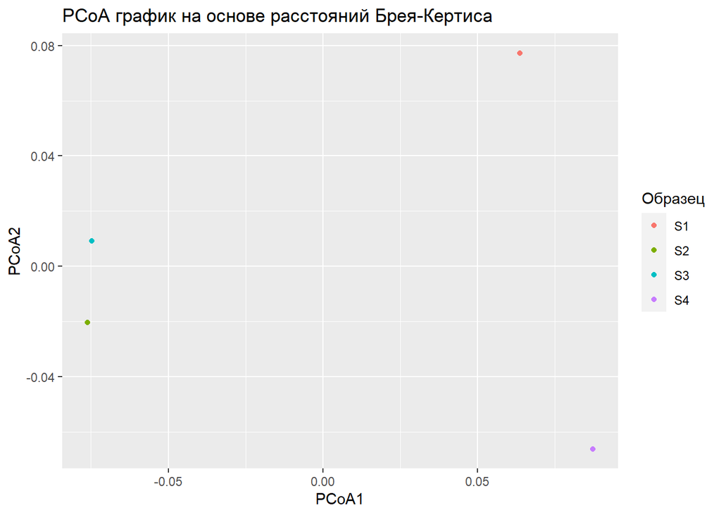

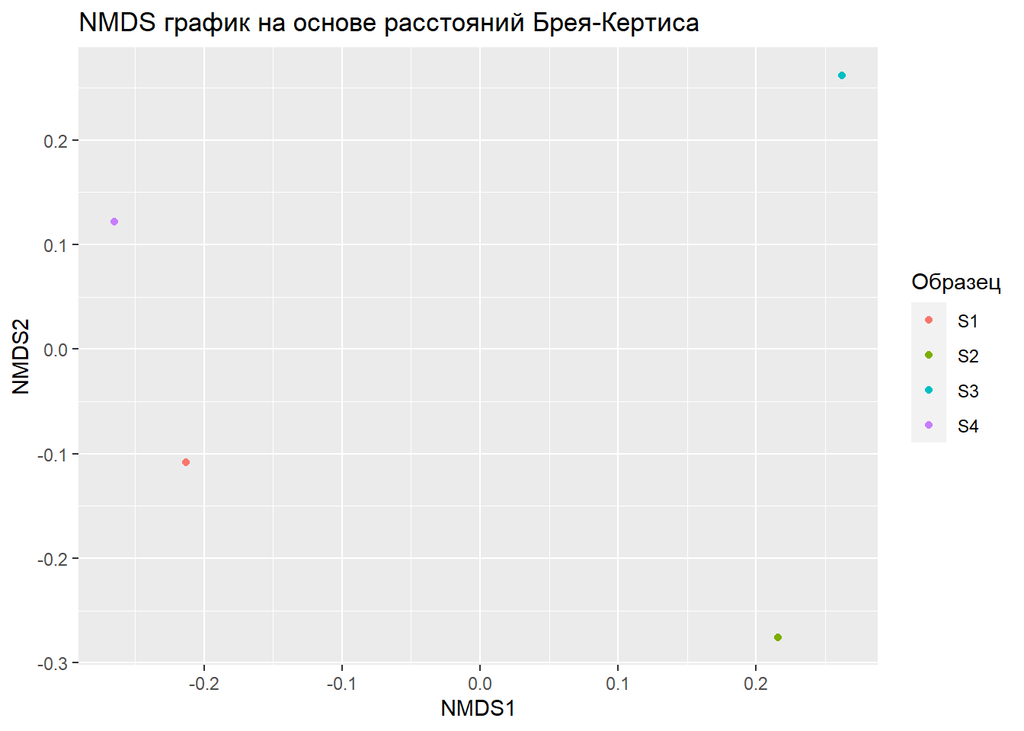